# Dissolution Data Analysis in R

Author

Sebastian Jakobsen, Sarah Mittenentzwei

# Introduction

This document walks through a complete dissolution-data workflow:

1. Setup and importing raw data
2. Convert absorbance → concentration
3. Calculate cumulative release
4. Compute mean & SD per time point
5. Plot dissolution profiles
6. (Optional) Fit a Weibull model

All steps include explanations and runnable R code.

# 1 Initial setup

**Setup R Project and load packages**

Make a folder on your computer with a suitable name (e.g. ‘FA503’ and a subfolder called ‘Dissolution’). Create an R-project; choose “existing folder” and browse to the folder ‘Dissolution’ you just created. This will set the working directory to this folder, which means that any files you save or import will be saved in this folder by default.

Make sure to import **tidyverse** for data manipulation.

```r
library(tidyverse)
```

**Importing data**

Save your dissolution data as a **CSV file** (Comma‑Separated Values) in your selected folder, for example:

```
dissolution_data.csv
```

This data set should contain the following columns:

- `tablet` — tablet ID number (e.g. 1-6).
- `time_min` — sampling time (minutes).
- `absorbance` — measured absorbance at the analytical wavelength.
- `dilution` — dilution factor applied to the sample.

Before we can begin any calculations, we need to load the raw dissolution dataset into R. CSV files can have different symbols for column separators and decimals. Depending on how your CSV is formatted, you have to use a different function to load the data:

- **Separator = comma and decimals = dot** (english standard): `data <- read_csv("dissolution_data.csv")`
- **Separator = semicolon and decimals = comma** (danish standard): `data <- read_csv2("dissolution_data.csv")`

If you don’t know how your data looks like, you can print the first 3 lines:

```r
cat(readLines("dissolution_data.csv", n = 3), sep = "\n")
```

```
tablet,weight_mg,time_min,absorbance,dilution
1,498,5,0.149,1
1,498,10,0.498,1
```

Use `read.csv()` or `read.csv2()` to import the data into a dataframe called `data`:

```r
data <- read.csv("dissolution_data.csv")
```

You can now inspect the dataset using `view()`:

```r
view(data)
```

**Defining constants**

Before starting the data analysis we want to define some constants that will be used in the calculations later on. These include the volume of the dissolution vessel, the sample volume, and the dose of API in each tablet.

```r
V_total  <- 900   # mL - volume of dissolution vessel
V_sample <- 5     # mL - volume of each sample
dose_mg  <- 200   # mg - Ibuprofen in each tablet
```

# 2 Convert absorbance → concentration

Given the following calibration curve for Ibuprofen:

$$y = -0.0002667 + 0.04478 x$$

Where `y = absorbance` and `x = concentration (µg/mL)`. The calibration curve is then used to convert absorbance values to concentrations (in mg/mL) by also correcting for the dilution factor.

```r
data <- mutate(data,
  conc_mg_ml = ((absorbance + 0.0002667) / 0.04478) * dilution / 1000
)
```

This creates a new column (`conc_mg_ml`) with the concentration of each sample at the different time points.

# 3 Calculate cumulative release

Now the cumulative released mass of Ibuprofen needs to be calculated. This is done by calculating the mass in the vessel (900 mL) at the current time point and adding the sum of the masses from the previous samples that have been withdrawn. The following equation illustrates how this is done:

$$m_{\text{released}} = V \cdot C_t + \sum_{i < t} (V_s \cdot C_i)$$
Where:

- $V$ is the volume of the dissolution vessel (here: **900 mL** of dissolution medium).
- $C_t$ is the concentration of the drug measured in the sample taken at **time (t)**.
- $V_s$ is the sample volume withdrawn at each sampling time (here: **5 mL**).
- $C_i$ represents the concentrations from all **previous sampling points** (i.e., for all (i < t)).

First we can start by determining the amount of Ibuprofen in the dissolution vessel ($V \cdot C_t$) at the different time points along with the masses removed with each sample ($C_i \cdot V_S$).

```r
data <- mutate(data,
  mass_in_vessel = conc_mg_ml * V_total,  # Mass in the vessel at the current time point
  sample_mg = conc_mg_ml * V_sample       # Mass removed with each sample
)
```

Now we want to calculate the cumulative release of Ibuprofen using the following code.

```r
# Arranges data set according to tablet number and time point (ascending)
data <- arrange(data, tablet, time_min)

# Groups data by tablet number - i.e. creates 6 separate mini datasets for each tablet
data <- group_by(data, tablet)

# Add new columns with mutate
data <- mutate(data,
  # Calculates the accumulated sum of mg of API removed by the previous samples.
  # lag() shifts the dataframe to only look at previous rows than the current row.
  # cumsum() calculates a cumulative sum of all the previous mg from samples.
  removed_before = lag(cumsum(sample_mg), default = 0),

  # Calculates the accumulated sum of mg released
  mg_released = mass_in_vessel + removed_before
)

# Remove grouping from the dataframe
data <- ungroup(data)
```

**The pipe operator**

In the above code, you take your data frame, alter it, and save it again under the name `data` multiple times. The pipe operator `%>%` can be used as an alternative to connect all the function you want to apply to `data`. Think of the pipe operator as **“and then”**. This way `data %>%` means you take your dataframe `data` **and then** perform the next line of code on this dataframe. Use the pipe operator after every function to apply them all after another.

```r
data <- data %>%

  arrange(tablet, time_min) %>%

  group_by(tablet) %>%

  mutate(
    removed_before = lag(cumsum(sample_mg), default = 0),
    mg_released = mass_in_vessel + removed_before

  ) %>%

  ungroup()
```

We have now created the column `mg_released` that contains the amount of Ibuprofen released at every time point. You can inspect the dataframe to see this and also notice how this is the sum of the columns `mass_in_vessel` and `removed_before`. You should also notice the connection between `removed_before` and `sample mg` (`removed_before` is the cumulative sum of `sample mg` starting from the previous row).

We can now create a new column that contains the % API released by comparing to the theoretical dose in each tablet (here, 200 mg of Ibuprofen).

```r
data <- mutate(data,
  percent_released = 100 * mg_released / dose_mg
)
```

# 4 Calculate mean & SD per time point

Now that the main data analysis is done, we want to calculate some basic summary statistics that can be used for plotting and visualizing the data. A new dataframe is created called `summary_data,` which contains the mean and standard deviation (SD) values of both the `mg_released` and `percent_released` for every time point.

```r
# Groups data by time points to calculate the mean and standard deviation
grouped_data <- group_by(data, time_min)

# Collapses data to one row per time point with mean and SD columns
summary_data <- summarise(grouped_data,
  # Calculates the mean mg released for each time point
  mean_mg = mean(mg_released),
  # Calculates the standard deviation of mg released for each time point
  sd_mg = sd(mg_released),
  # Calculates the mean % released for each time point
  mean_pct = mean(percent_released),
  # Calculates the standard deviation of % released for each time point
  sd_pct = sd(percent_released)
)
```

You can now inspect the new dataframe `summary_data` to see what the above code has outputted.

# 5 Plot dissolution profiles

We can now plot the dissolution profiles using `ggplot`. First the mg of Ibuprofen released as a function of time is plotted as a line plot.

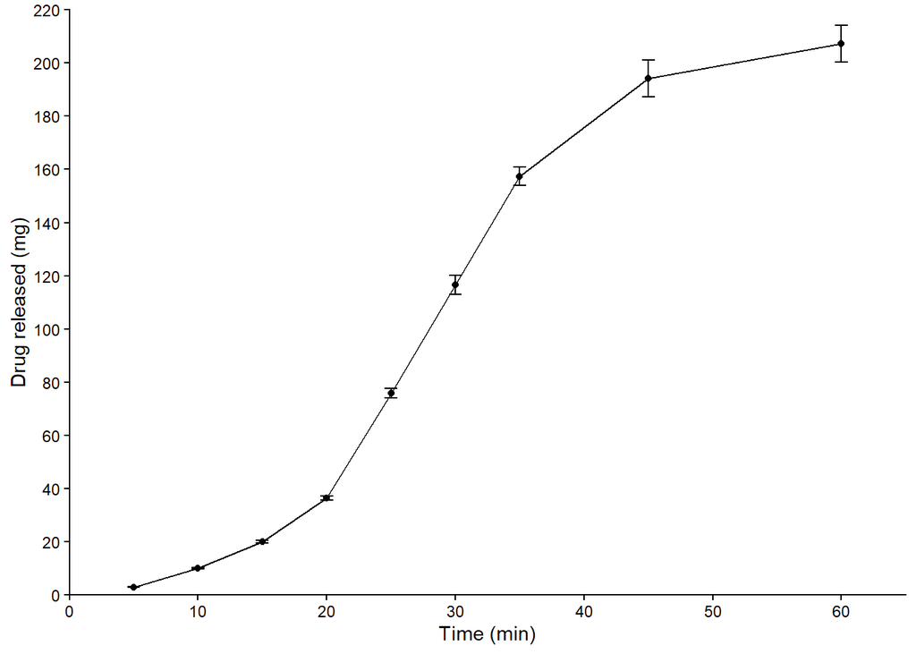

```r
# Assigns the plot to a variable so we can save it later
plot_mg <- ggplot(

  # Defines which dataframe to be used for plotting
  # aes() is used to map valaues to the x- and y-coordinates
  summary_data, aes(x=time_min, y=mean_mg)) +

  # Creates lines between the plotted values
  geom_line() +

  # Creates a dot for every data point
  geom_point() +

  # Creates the error bars equal to one SD above and below the mean
  # width controls how wide the horizontal caps on the error bar are
  geom_errorbar(aes(ymin = mean_mg - sd_mg,
                    ymax = mean_mg + sd_mg),
                width = 1) +

  labs(
       # Gives the x-axis a title
       x = "Time (min)",

       # Gives the y-axis a title
       y = "Drug released (mg)") +

  # Controls the x-axis limits and tick positions
  scale_x_continuous(limits = c(0, 65),
                     breaks = seq(0, 65, by = 10),
                     expand = c(0, 0)) +

  # Controls the y-axis limits and tick positions
  scale_y_continuous(limits = c(0, 220),
                     breaks = seq(0, 220, by = 20),
                     expand = c(0, 0)) +

  # Uses a classic theme for the plot
  theme_classic()

# We call the plot to show it
plot_mg
```

The same can now be done using the % released instead.

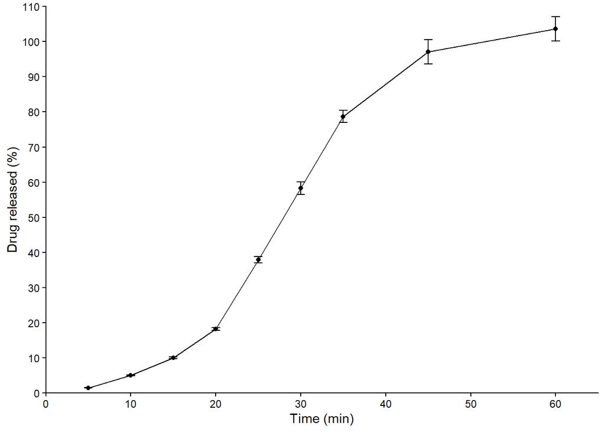

```r
plot_pct <- ggplot(
  summary_data, aes(x=time_min, y=mean_pct)) +
  geom_line() +
  geom_point() +
  geom_errorbar(aes(ymin = mean_pct - sd_pct,
                    ymax = mean_pct + sd_pct),
                width = 1) +
  labs(x = "Time (min)",
       y = "Drug released (%)") +
  scale_x_continuous(limits = c(0, 65),
                     breaks = seq(0, 65, by = 10),
                     expand = c(0, 0)) +
  scale_y_continuous(limits = c(0, 110),
                     breaks = seq(0, 110, by = 10),
                     expand = c(0, 0)) +
  theme_classic()

plot_pct
```

We can now save the two plots to our computer in the working directory defined at the beginning:

```r
# The filename which the plot will be saved under.
# Here .png is used but other filetypes can be used
ggsave("dissolution_mg_plot.png",

       # The plot we want to save.
       plot = plot_mg,

       # Here we can define the size and resolution of the picture
       width = 6, height = 4, dpi = 300)

# The same is done for the % plot
ggsave("dissolution_percent_plot.png",
       plot = plot_pct,
       width = 6, height = 4, dpi = 300)
```

# 6 (Optional) Fit a Weibull model

Optionally, we can try to fit a model to our dissolution dataset. While there exist multiple models to fit dissolution data (see the following [Link](https://saspublishers.com/media/articles/SAJP35388-396.pdf=) for a review of models), we will here use the Weibull model:

$$M(t) = M_0 \cdot (1-e^{-(\frac{t}{\alpha})^\beta})$$
Where:

- $M(t)$ is the amount/percentage of drug released at time $t$.
- $M_0$ is the maximum amount of drug released (e.g. 100%).
- $\alpha$ is a scale parameter related to time (the time where 63.2% is released, so a higher $\alpha$ = slower dissolution).
- $\beta$ is a shape parameter that controls the shape of the curve ($\beta$ < 1 → parabolic curve, $\beta$ = 1 → exponential curve, $\beta$ > 1 → sigmoidal (S-shaped) curve).

First, we define the Weibull function. $M_0$ is set to `100` as we will be fitting to the % released data.

```r
weibull_fun <- function(t, alpha, beta){
  100 * (1 - exp(-(t/alpha)^beta))
}
```

Then we fit the Weibull model to our data using the non linear fitting function `nls()` (**N**onlinear **L**east **S**quares)

```r
fit <- nls(
  # nls() attempts to find parameter values (here: alpha and beta) that make the model match
  # the observed data as closely as possible.
  # Notice that the variable names from the data set are used (mean_pct and time_min)
  mean_pct ~ 100 * (1 - exp(-(time_min/alpha)^beta)),

  # The dataset we are fitting our model to
  data = summary_data,

  # Nonlinear models need initial guesses to start fitting.
  # They don't have to be perfect but need to be reasonable
  start = list(alpha = 30, beta = 2)
)
```

We can now inspect the output created by `nls()` saved in the variable `fit`. `summary()` gives a nice overview of the formula used, the best fit parameters and their associated standard error. If we just want to access the fitted paramaters `coef()` is used.

```r
summary(fit)
```

```
Formula: mean_pct ~ 100 * (1 - exp(-(time_min/alpha)^beta))

Parameters:
      Estimate Std. Error t value Pr(>|t|)
alpha  31.0564     0.3331   93.23  4.3e-12 ***
beta    3.4090     0.1723   19.79  2.1e-07 ***
---
Signif. codes:  0 '***' 0.001 '**' 0.01 '*' 0.05 '.' 0.1 ' ' 1

Residual standard error: 2.147 on 7 degrees of freedom

Number of iterations to convergence: 6
Achieved convergence tolerance: 2.712e-06
```

```r
coef(fit)
```

```
    alpha      beta
31.056407  3.408984
```

When wanting to assess how well the nonlinear fit fits the data, the best way is to plot it. Firstly, we need to create a dataset containing predicted values based on the fit, which can be shown as a fitted curve on the plot.

```r
# To get a smooth curve, 200 equally spaced time points are created between 0 and 60.
t_smooth <- seq(0, 60, length.out = 200)

# The parameters of the fit (alpha and beta) is stored in a variable named 'params'
params <- coef(fit)

# The Weibull function is used to calculate a series of corresponding y-values to the
# t_smooth x-values using the alpha and beta values from the fit
predicted <- weibull_fun(
  t_smooth,
  params["alpha"],
  params["beta"]
)

# These new x-values and preedicted y-values are stored in anew dataframe (fit_df)
fit_df <- data.frame(time = t_smooth,
                     percent_released = predicted)
```

Now we just need to plot the fit along with the observed data using `ggplot`. Here the observed data will be plotted as dots, while the predicted values are shown as a fitted line.

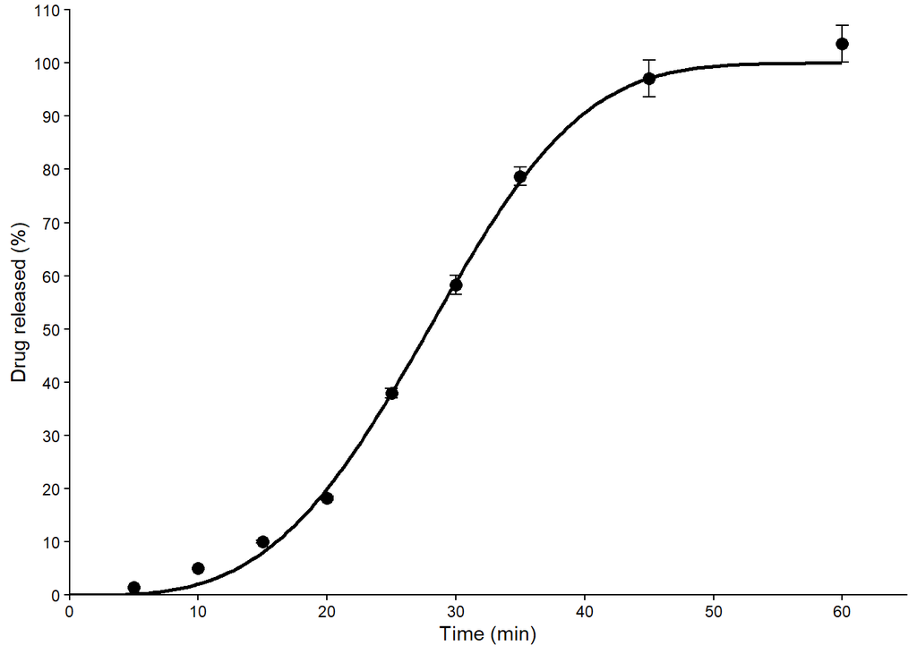

```r
ggplot() +

  # The observed data stored in 'summary_data' is plotted as dots
  geom_point(data = summary_data,
             aes(time_min, mean_pct),
             size = 3) +

  # The predicted values stored in 'fit_df' is plotted as line.
  # The many data point will end up giving a smooth line
  geom_line(data = fit_df,
            aes(time, percent_released),
            linewidth = 1) +

  # SD error bars are plotted as before
  geom_errorbar(data = summary_data,
                aes(x = time_min,
                    ymin = mean_pct - sd_pct,
                    ymax = mean_pct + sd_pct),
                width = 1) +

  # Axis labels for the plot
  labs(x = "Time (min)",
       y = "Drug released (%)") +

  #Scaling of axis
  scale_x_continuous(limits = c(0, 65),
                     breaks = seq(0, 65, by = 10),
                     expand = c(0, 0)) +
  scale_y_continuous(limits = c(0, 110),
                     breaks = seq(0, 110, by = 10),
                     expand = c(0, 0)) +

  theme_classic()
```